# Truth Versus Truth

June 1, 2019

## Problem

- Wikipedia is a go-to source for information
- Edited by the comunity
- Consensus based
- This paper presents a methodology for critical analysis of wikipedia content

## About the Research

- Analyses performed using R and Rstudio (both open source)
- All source code and data available online: https://github.com/dietrichson/ila2019
  - Reproduce
  - Replicate
  - Reuse

## Wikipedia API

- Wikipedia publishes an API (Application Programming Interface)
- Allows open access to content, including revisions in a machine readable format

```r
wp_c <- revision_content("en","wikipedia", revisions = 552373187)
```

## What is “a Lot”

- One of the ways to detect a controversial topic is that it has *a lot* of edits
- What is *a lot*?
- A baseline needs to be established
- Sample: 1000 random pages from each of:
  - English
  - Spanish
  - Catalan
  - Portuguese
  - Galician (Galego)
  - Esperanto
  - French
  - Basque

## Baseline

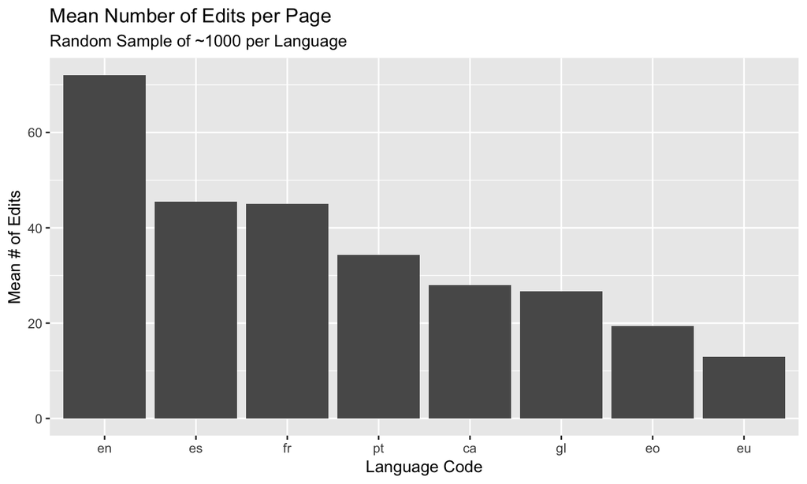

## L1 and L2 Speakers

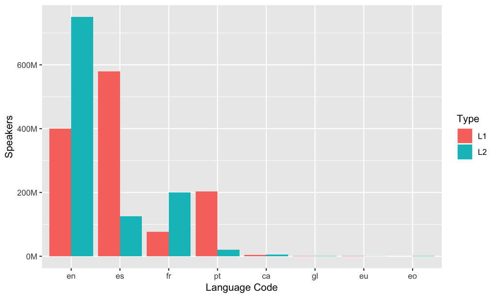

## Smaller languages

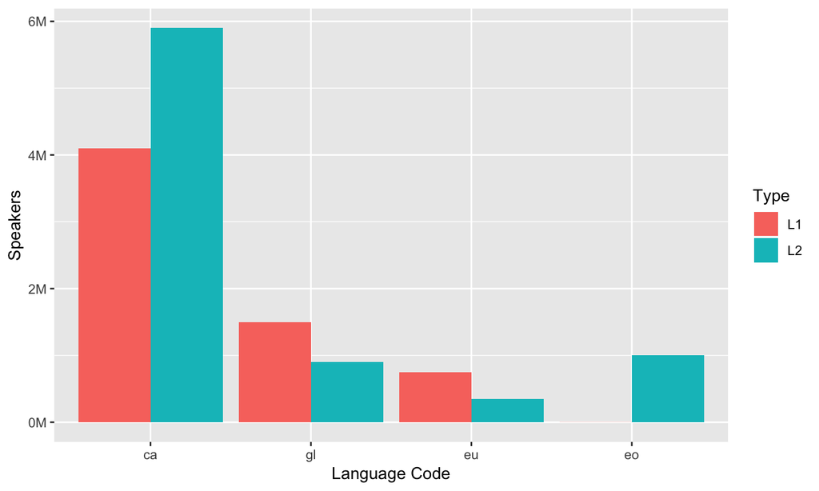

## Variability

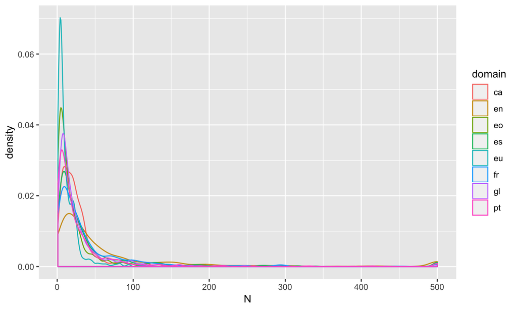

## Variability

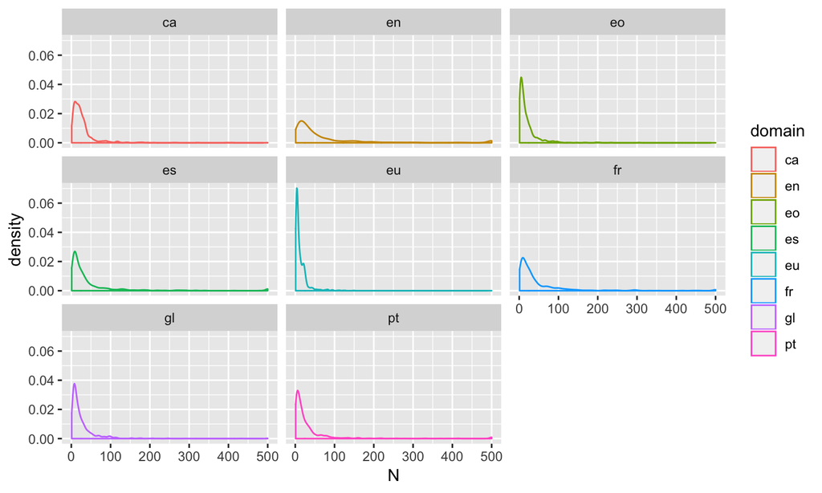

## Distribution of Contributions - Overall

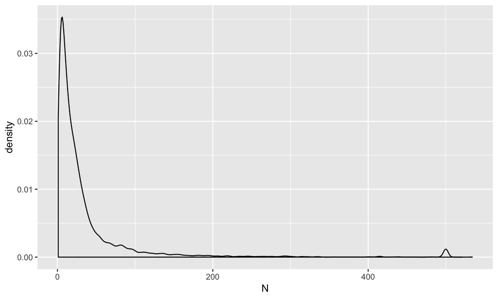

## Distribution of Contributions - Overall

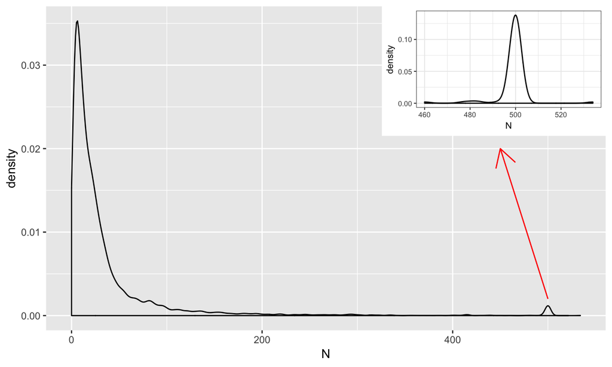

- Why the bulge?

## API Limits

- When an article has more than 500 edits the API returns the first 500
- A better measure is needed
- Unit: Edit per Day
- 1 EPD ≈ 11.6 µHz (microhertz)
- Corollary: You can calculate \(\lambda\) (wavelength)

## Edits per Day

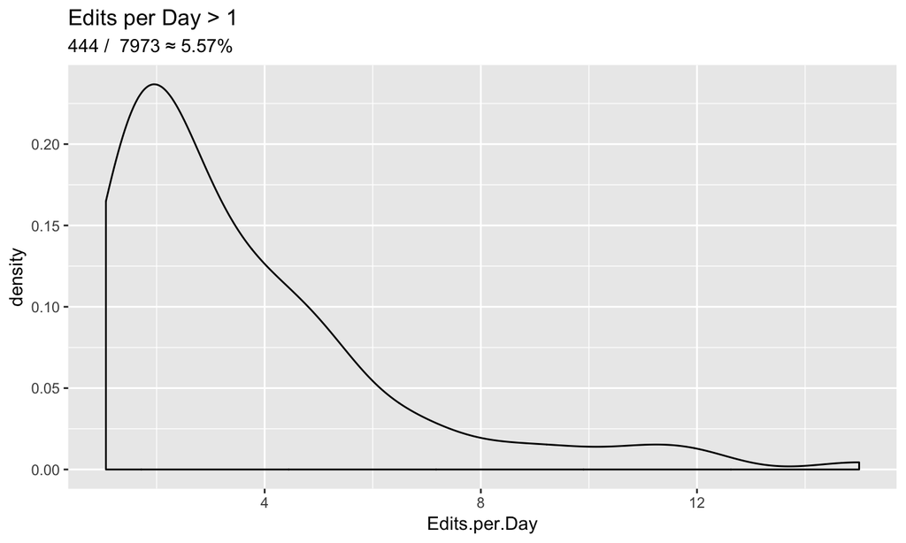

- Roughly 5.6% of articles get updated more than once a day.
- Perhaps an indicator of controversy

## Catalonian Independence: A Controversial Topic

- Spain has 17 *Autonomías*, with higher or lesser degree of self-rule
- There are also 18 active separatist/independence movements!
- Two are well known internationally: Basque and Catalonia.
- Catalonian separatists made a bid for indepencence in 2017 with a referendum
- Full disclosure (bias alert):
  - I am not in favor of independence (*constitutionalist* / *monarquist*)
  - Indepence would probably not affect me
  - Not a particularly strongly held opinion

## Data

- “Same” page on wikipedia in nine different languages
  - https://en.wikipedia.org/wiki/2017_Catalan_independence_referendum
  - https://es.wikipedia.org/wiki/Refer%C3%A9ndum_de_independencia_de_Catalu%C3%B1a_de_2017
  - https://ca.wikipedia.org/wiki/Refer%C3%A8ndum_sobre_la_independ%C3%A8ncia_de_Catalunya
  - https://eu.wikipedia.org/wiki/Kataluniaren_independentziarako_2017ko_erreferenduma
  - https://pt.wikipedia.org/wiki/Referendo_sobre_a_independ%C3%AAncia_da_Catalunha_em_2017
  - https://eo.wikipedia.org/wiki/Referendumo_pri_sendependi%C4%9Do_de_Katalunio_en_2017
  - https://fr.wikipedia.org/wiki/R%C3%A9f%C3%A9rendum_de_2017_sur_l%27ind%C3%A9pendance_de_la_Catalogne
  - https://gl.wikipedia.org/wiki/Referendo_sobre_a_independencia_de_Catalu%C3%B1a_de_2017
  - https://sco.wikipedia.org/wiki/Catalan_unthirldom_referendum,_2017

## Data

- “Same” was defined as *Wikipedia* does

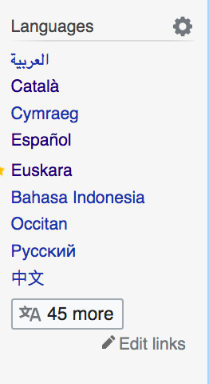

Select Language

## Edits per Day

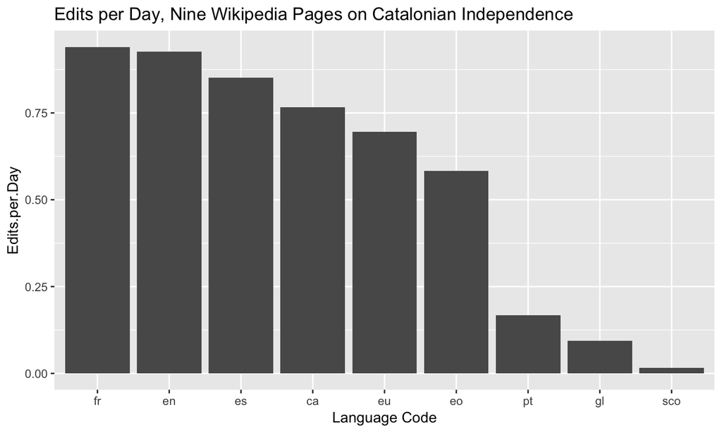

## Size of Change per Day

[figure not shown]

## Timelines

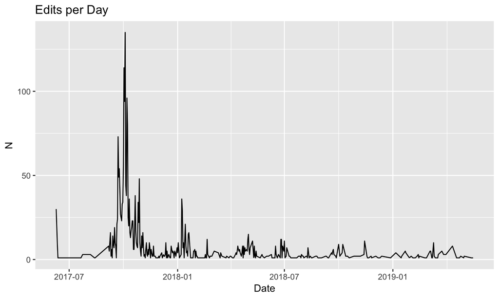

## Timelines

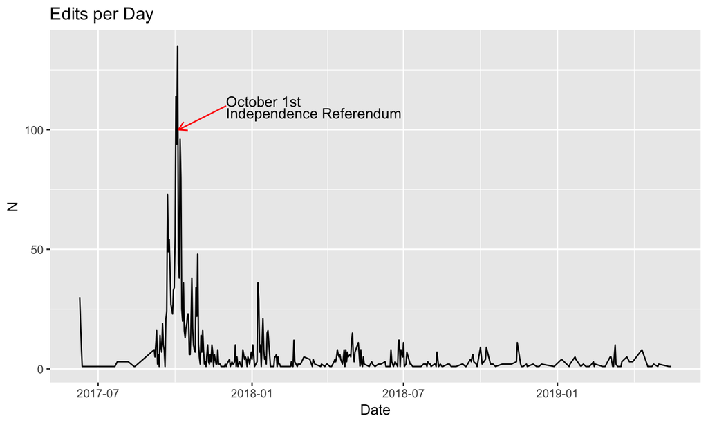

## Zooming in

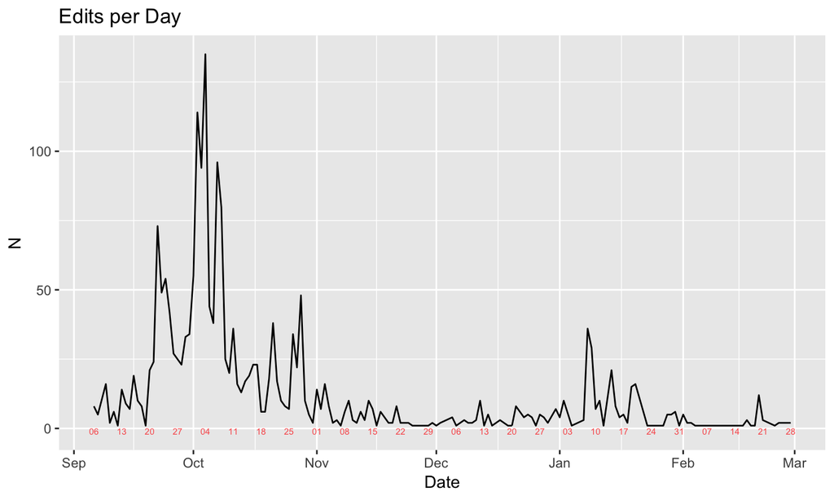

## Zooming in

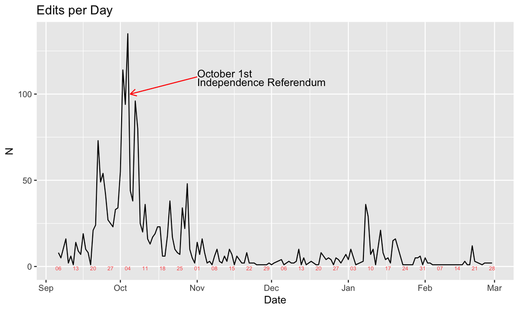

## Zooming in

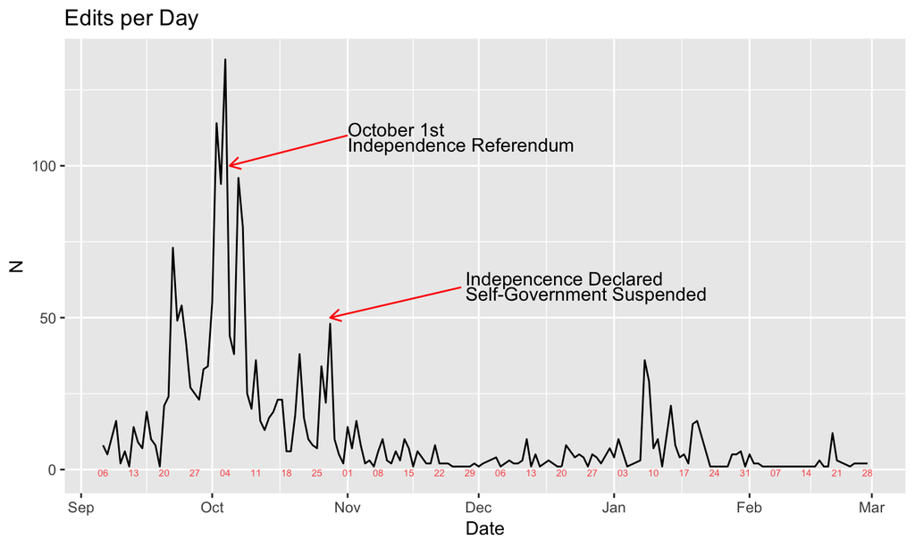

## Zooming in

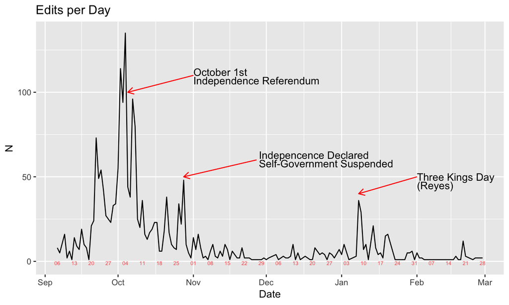

## By Domain (Language)

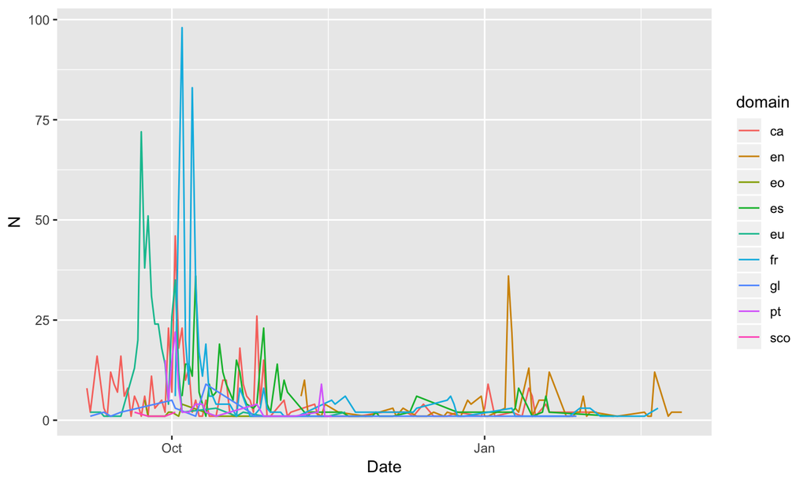

## By Domain (Language)

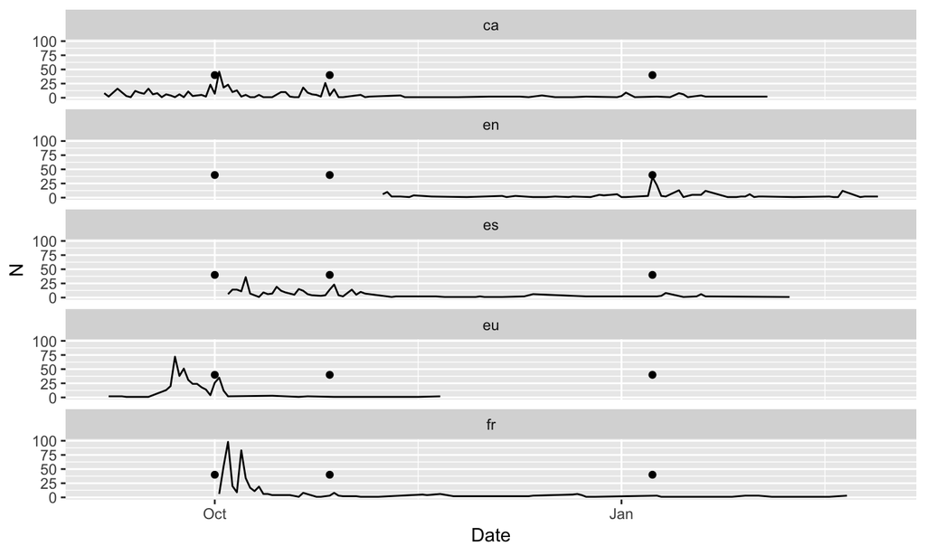

## Controversy Detected

- Wikipedia publishes a warning
- Only in the English version

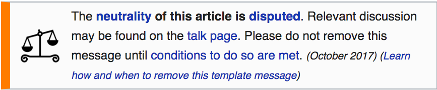

Disputed

## Sentiment Analysis (Classic)

- Uses lexicon for each language
- Most are public domain (OS)
- Assigns a positive, negative or neutral value to each word
- More sophisticated algorithms take n-grams into account (computationally more expensive)

## Sentiment Analysis (Classic)

```r
lapply(1:7,function(i){
  myPage <- read_html(myData[[i]])
  myPage %>% html_node('title') %>% html_text() -> title
  myPage %>% html_node("body") %>% html_text() -> body
  mySentences <- get_sentences(body)
  out <- get_nrc_sentiment(mySentences, language = myDF$language[i])
  out$title <- title
  out$domain <- myDF$domain[i]
  out$sentences <- mySentences
  out
}) %>%
  bind_rows() -> myAnalysis
```

## Sentiment Analysis (Classic)

| Domain | # Sentences | Pos. | Neg. | Abs. | Rel. |
| --- | --- | --- | --- | --- | --- |
| ca | 750 | 286 | 98 | 188 | 0.2506667 |
| en | 1572 | 807 | 431 | 376 | 0.2391858 |
| eo | 139 | 19 | 15 | 4 | 0.0287770 |
| es | 1386 | 898 | 465 | 433 | 0.3124098 |
| eu | 739 | 151 | 104 | 47 | 0.0635995 |
| fr | 406 | 371 | 351 | 20 | 0.0492611 |
| pt | 68 | 59 | 31 | 28 | 0.4117647 |

## Sentiment Analysis (Classic)

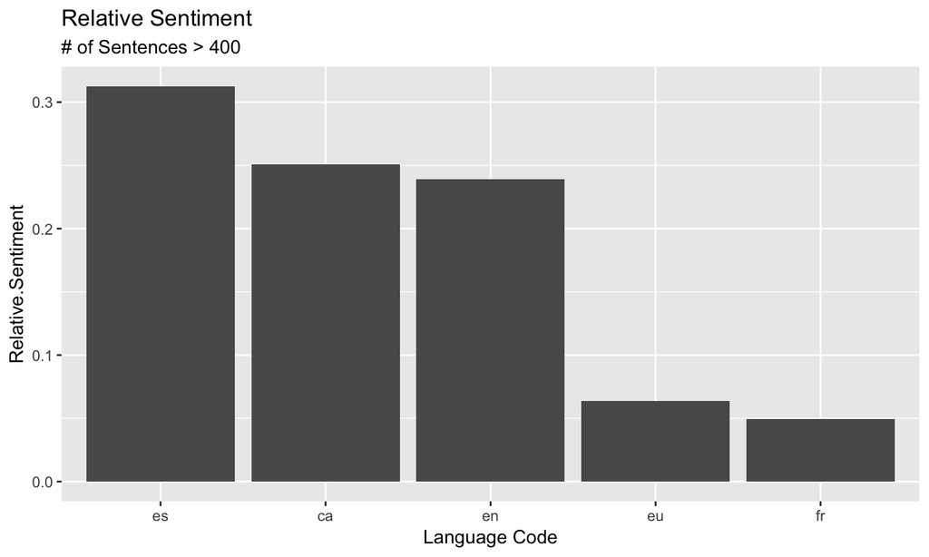

## Multidimensional Sentiment Analysis

- *syuzhet* package implements multidimensional sentiment analysis
- Includes specificity for eight emotions: -Anger -Anticipation -Disgust -Fear -Joy -Sadness -Surprise -Trust

## Multidimensional Sentiment Analysis

|  | Anger | Anticipation | Disgust | Fear | Joy | Sadness | Surprise | Trust |
| --- | --- | --- | --- | --- | --- | --- | --- | --- |
| ca | 53 | 70 | 11 | 80 | 50 | 34 | 18 | 205 |
| en | 233 | 304 | 66 | 330 | 195 | 192 | 199 | 629 |
| eo | 3 | 4 | 2 | 14 | 5 | 4 | 0 | 12 |
| es | 184 | 254 | 165 | 291 | 181 | 188 | 130 | 696 |
| eu | 38 | 28 | 33 | 53 | 18 | 40 | 28 | 69 |
| fr | 141 | 156 | 66 | 208 | 77 | 135 | 81 | 324 |
| pt | 14 | 21 | 14 | 19 | 12 | 14 | 5 | 46 |

## Example: Surprise

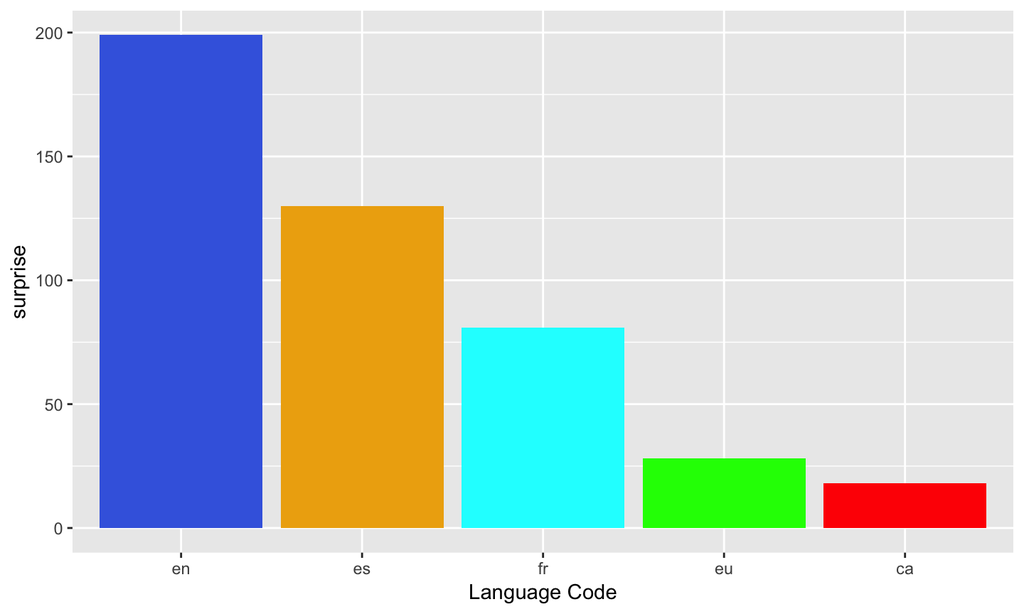

## Example: Anger

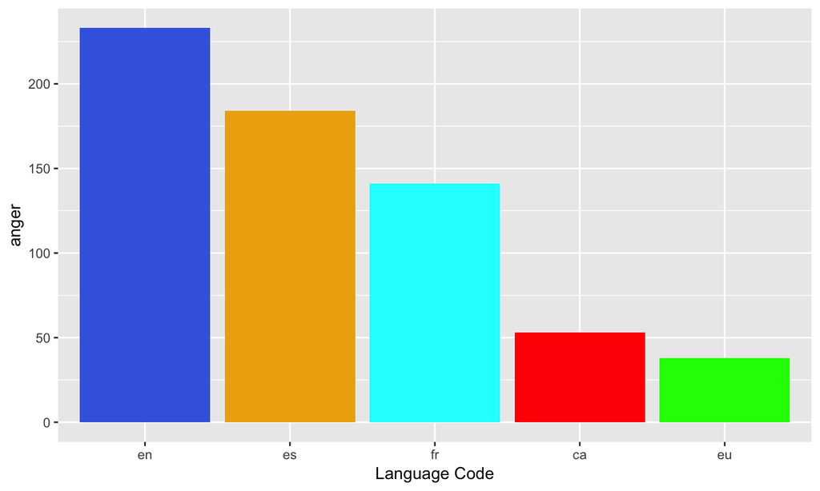

## Example: Disgust

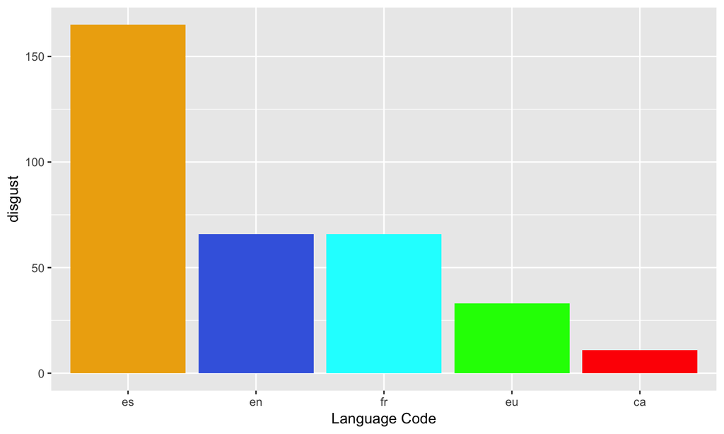

## Complete Profile

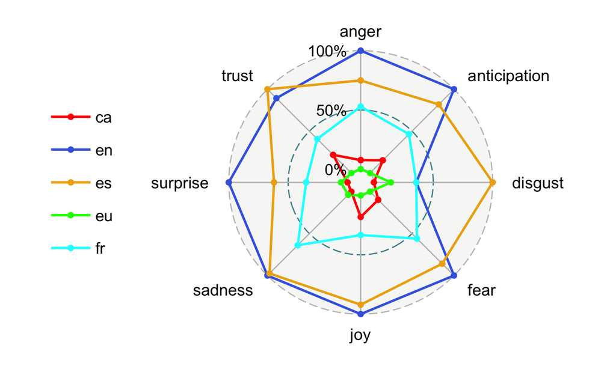

## Shibboleth Detection

- Determine one/several words that will identify you as belonging to one group or another
- Referendum was deemed illegal by the Spanish courts, so *illegal* might work as a *shibboleth*.

## Shibboleth Detection

| domain | word | times |
| --- | --- | --- |
| es | ilegal | 20 |
| en | illegal | 12 |
| fr | illégal | 10 |
| ca | il·legal | 5 |
| eu | legez | 4 |
| pt | ilegal | 2 |

## Shibboleth Detection

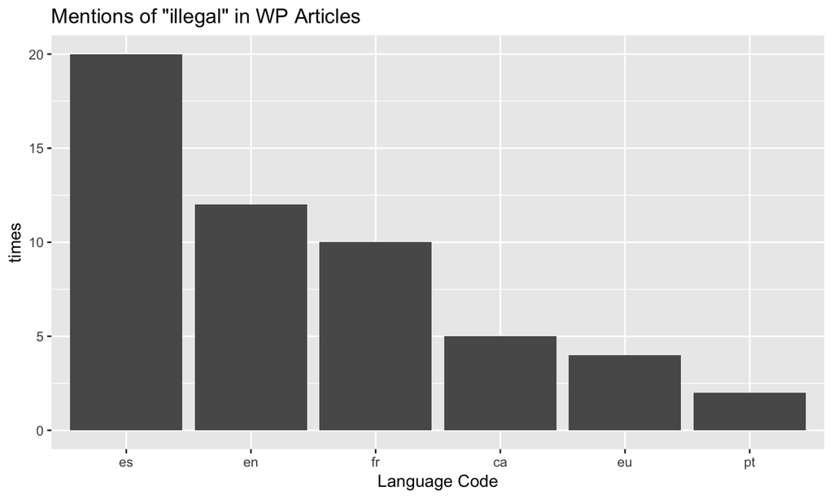

## Conclusions

- Wikipedia being community edited may lead to bias
- Critical reading may uncover this
- Quantitative methodologies allows for access to *bias-indicators*
  - At scale
  - In languages unknown to the researcher